# Merging CIMIS Data

```r
rm(list=ls())

require(stringr)
require(zoo)
require(openair)


na.count<-function(x) sum(is.na(x))
na.mean<-function(x) ifelse(is.nan(mean(x,na.rm=T)),NA,mean(x,na.rm=T))

library(REddyProc)

library(car)
library(stringr)

library(tidyverse)
library(ggpubr)
library(rstatix)
library(broom)
library(psych)

library(lme4)
library(dplyr)
```

# Defining the data I/O directory

```r
## change root.path as needed
root.path<-"C:\\Users\\tfens\\R_REPOS\\Flux_processing\\Concord_R_Code\\Concord_Post_Process\\"
#root.path<-"D:\\Housen\\Flux\\Data-exploring\\02_Concord\\"

combined.path<-paste0(root.path,"01_Data\\03_combined_data\\") ## this is where the combined data lives


path.in_CIMIS<-paste0(root.path,"01_Data\\04_CIMIS_Data\\")
 ver<-"cimis_data"

# hc: Use this for storing combined file
path.out<-paste0(root.path,"02_output\\04_CIMIS_gapfill\\",sep="")
```

#defining specific files

```r
## use follows to specify the versions of the combined file
# file name of the combined_file
cdata.file_combo<-paste0("2023-10-13_master_eddy_met_concord_postfiltering.csv")



## use follows to specify the version of the
file.name_cimis<-paste("hourly_CIMIS.csv")
```

# Read in Combined fulloutput file

# parse variable names and define N/As

```r
## read in full output file
eddy_met<-read.csv(paste0(combined.path, cdata.file_combo,sep=""),

                header=T,
                na.strings="NA",
                stringsAsFactors=F)
colnames(eddy_met)<-colnames(read.csv(paste(combined.path,cdata.file_combo,sep=""),

                                   header=T,
                                   na.strings="NA"))



head(eddy_met)
```

|  | time.id | TIMESTAMP | filename | date | time | DOY | daytime | file_records | used_records | Tau | qc_Tau | H | qc_H | LE | qc_LE | co2_flux | qc_co2_flux | h2o_flux | qc_h2o_flux | H_strg | LE_strg | co2_strg | h2o_strg | co2_v.adv | h2o_v.adv | co2_molar_density | co2_mole_fraction | co2_mixing_ratio | co2_time_lag | … |
| --- | --- | --- | --- | --- | --- | --- | --- | --- | --- | --- | --- | --- | --- | --- | --- | --- | --- | --- | --- | --- | --- | --- | --- | --- | --- | --- | --- | --- | --- | --- |
| 1 | 2019.495 | 7/1/2019 0:00 | 2019-06-30T233000_smart3-00177.ghg | 7/1/2019 | 0:00 | 182.0000 | 0 | 18000 | 18000 | -0.161742 | 0 | -36.9636 | 0 | 13.31220 | 0 | 2.00925 | 0 | 0.300071 | 0 | 0.179553 | -0.015000 | 0.030300 | -0.000338 | -9.53e-11 | -2.54e-12 | 16.6464 | 398.570 | 402.846 | 0 | … |
| 2 | 2019.495 | 7/1/2019 0:30 | 2019-07-01T000000_smart3-00177.ghg | 7/1/2019 | 0:30 | 182.0208 | 0 | 18000 | 18000 | -0.223893 | 0 | -67.1903 | 1 | 32.60920 | 1 | 3.70433 | 1 | 0.734689 | 1 | -1.257440 | 1.371800 | 0.077000 | 0.030900 | 1.62e-10 | 4.46e-12 | 16.7133 | 399.478 | 403.912 | 0 | … |
| 3 | 2019.495 | 7/1/2019 1:00 | 2019-07-01T003000_smart3-00177.ghg | 7/1/2019 | 1:00 | 182.0416 | 0 | 18000 | 18000 | -0.123429 | 0 | -31.6904 | 0 | 3.27048 | 1 | 1.52647 | 0 | 0.073600 | 1 | -2.081560 | 0.081100 | 0.020400 | 0.001830 | 3.87e-11 | 1.07e-12 | 16.7701 | 399.718 | 404.164 | 0 | … |
| 4 | 2019.495 | 7/1/2019 1:30 | 2019-07-01T010000_smart3-00177.ghg | 7/1/2019 | 1:30 | 182.0624 | 0 | 18000 | 18000 | -0.116504 | 1 | -40.3635 | 0 | 11.78860 | 1 | 1.42457 | 0 | 0.265454 | 1 | 0.664646 | -0.137058 | -0.013400 | -0.003090 | -3.12e-11 | -8.56e-13 | 16.7477 | 399.560 | 403.989 | 0 | … |
| 5 | 2019.495 | 7/1/2019 2:00 | 2019-07-01T013000_smart3-00177.ghg | 7/1/2019 | 2:00 | 182.0833 | 0 | 18000 | 18000 | -0.143155 | 0 | -25.2746 | 0 | NA | 2 | 1.54148 | 0 | NA | 2 | -2.911480 | 3.282810 | -0.000759 | 0.073800 | 5.34e-11 | 1.58e-12 | 16.8143 | 399.551 | 404.334 | 0 | … |
| 6 | 2019.495 | 7/1/2019 2:30 | 2019-07-01T020000_smart3-00177.ghg | 7/1/2019 | 2:30 | 182.1041 | 0 | 18000 | 18000 | -0.100744 | 0 | -35.0211 | 0 | 5.26757 | 0 | 1.47403 | 0 | 0.118459 | 0 | -0.493139 | 0.128214 | -0.027500 | 0.002880 | 2.53e-11 | 7.52e-13 | 16.8100 | 399.229 | 404.022 | 0 | … |

```r
tail(eddy_met)
```

|  | time.id | TIMESTAMP | filename | date | time | DOY | daytime | file_records | used_records | Tau | qc_Tau | H | qc_H | LE | qc_LE | co2_flux | qc_co2_flux | h2o_flux | qc_h2o_flux | H_strg | LE_strg | co2_strg | h2o_strg | co2_v.adv | h2o_v.adv | co2_molar_density | co2_mole_fraction | co2_mixing_ratio | co2_time_lag | … |
| --- | --- | --- | --- | --- | --- | --- | --- | --- | --- | --- | --- | --- | --- | --- | --- | --- | --- | --- | --- | --- | --- | --- | --- | --- | --- | --- | --- | --- | --- | --- |
| 45233 | 2022.075 | 1/28/2022 8:00 | 2022-01-28T073000_smart3-00177.ghg | 1/28/2022 | 8:00 | 28.3332 | 1 | 18000 | 18000 | -0.007500 | 1 | 3.17482 | 1 | -4.43941 | 1 | 1.61443 | 1 | -0.098800 | 1 | -0.823420 | 0.170711 | 0.192718 | 0.003800 | -1.12e-11 | -1.65e-13 | NA | 460.356 | 463.513 | 0.0 | … |
| 45234 | 2022.075 | 1/28/2022 8:30 | 2022-01-28T080000_smart3-00177.ghg | 1/28/2022 | 8:30 | 28.3541 | 1 | 18000 | 18000 | -0.021600 | 1 | NA | 2 | 2.54501 | 1 | -1.86448 | 1 | 0.056700 | 1 | 4.627780 | 2.316480 | -1.241380 | 0.051600 | -6.68e-11 | -1.11e-12 | NA | 446.438 | 449.762 | 0.0 | … |
| 45235 | 2022.075 | 1/28/2022 9:00 | 2022-01-28T083000_smart3-00177.ghg | 1/28/2022 | 9:00 | 28.3749 | 1 | 18000 | 18000 | -0.047300 | 1 | NA | 2 | 17.54370 | 1 | -25.68040 | 1 | 0.392105 | 1 | 7.450570 | 2.794030 | -0.679411 | 0.062400 | -2.19e-10 | -4.03e-12 | NA | 438.743 | 442.324 | -0.2 | … |
| 45236 | 2022.075 | 1/28/2022 9:30 | 2022-01-28T090000_smart3-00177.ghg | 1/28/2022 | 9:30 | 28.3957 | 1 | 18000 | 18000 | -0.199863 | 1 | NA | 2 | 74.17960 | 1 | NA | 2 | 1.662940 | 1 | 8.075920 | -0.025300 | 1.353070 | -0.000568 | -1.58e-10 | -2.81e-12 | NA | 454.240 | 457.945 | 0.0 | … |
| 45237 | 2022.075 | 1/28/2022 10:00 | 2022-01-28T093000_smart3-00177.ghg | 1/28/2022 | 10:00 | 28.4165 | 1 | 18000 | 18000 | -0.056100 | 0 | 2.08207 | 1 | 71.55290 | 0 | -11.78560 | 0 | 1.606590 | 0 | 4.197770 | 1.622180 | -1.926450 | 0.036400 | 4.77e-11 | 9.40e-13 | NA | 432.053 | 435.761 | 0.0 | … |
| 45238 | 2022.075 | 1/28/2022 10:30 | 2022-01-28T100000_smart3-00177.ghg | 1/28/2022 | 10:30 | 28.4374 | 1 | 18000 | 18000 | -0.058100 | 0 | 11.61380 | 0 | 78.66280 | 0 | -14.39930 | 0 | 1.765950 | 0 | -0.430646 | 0.801176 | -0.391268 | 0.018000 | 3.44e-11 | 7.00e-13 | 18.3202 | 427.550 | 431.309 | 0.0 | … |

```r
NA
```

#Read in CIMIS File

```r
## read in CIMIS file
cimis_data<-read.csv(paste0(path.in_CIMIS, file.name_cimis,sep=""),
                     header = T,
                     skip = 1)



colnames(cimis_data)<-colnames(read.csv(paste(path.in_CIMIS,file.name_cimis,sep=""),

                                   header=T,
                                   na.strings="NA"))



head(cimis_data)
```

|  | Stn.Id | Stn.Name | CIMIS.Region | Date | Hour | DOY | ETo | qc | Precip | qc.1 | Sol.Rad | qc.2 | Net.Rad | qc.3 | Vap.Pres | qc.4 | Air.Temp | qc.5 | Rel.Hum | qc.6 | Dew.Point | qc.7 | Wind.Speed | qc.8 | Res.Wind.Speed..m.s. | qc.9 | Wind.Dir | qc.10 | Wind.Dir.Std.Dev | … |
| --- | --- | --- | --- | --- | --- | --- | --- | --- | --- | --- | --- | --- | --- | --- | --- | --- | --- | --- | --- | --- | --- | --- | --- | --- | --- | --- | --- | --- | --- | --- |
| 1 | 170 | Concord | San Francisco Bay | 7/1/2019 | 100 | 182 | 0 |  | 0 |  | 0 |  | -40 |  | 1.4 |  | 14.6 |  | 82 |  | 11.7 |  | 2.2 |  | 1.9 |  | 190 |  | 27 | … |
| 2 | 170 | Concord | San Francisco Bay | 7/1/2019 | 200 | 182 | 0 |  | 0 |  | 0 |  | -40 |  | 1.4 |  | 14.2 |  | 84 |  | 11.5 |  | 2.0 |  | 1.6 |  | 208 |  | 37 | … |
| 3 | 170 | Concord | San Francisco Bay | 7/1/2019 | 300 | 182 | 0 |  | 0 |  | 0 |  | -40 |  | 1.4 |  | 14.0 |  | 85 |  | 11.4 |  | 2.2 |  | 1.9 |  | 211 |  | 30 | … |
| 4 | 170 | Concord | San Francisco Bay | 7/1/2019 | 400 | 182 | 0 |  | 0 |  | 0 |  | -40 |  | 1.4 |  | 13.9 |  | 85 |  | 11.5 |  | 2.0 |  | 1.6 |  | 213 |  | 37 | … |
| 5 | 170 | Concord | San Francisco Bay | 7/1/2019 | 500 | 182 | 0 |  | 0 |  | 3 |  | -38 |  | 1.4 |  | 13.7 |  | 87 |  | 11.7 |  | 2.0 |  | 1.6 |  | 192 |  | 36 | … |
| 6 | 170 | Concord | San Francisco Bay | 7/1/2019 | 600 | 182 | 0 |  | 0 |  | 31 |  | -17 |  | 1.4 |  | 14.0 |  | 87 |  | 11.8 |  | 2.1 |  | 1.6 |  | 199 |  | 39 | … |

```r
tail(cimis_data)
```

|  | Stn.Id | Stn.Name | CIMIS.Region | Date | Hour | DOY | ETo | qc | Precip | qc.1 | Sol.Rad | qc.2 | Net.Rad | qc.3 | Vap.Pres | qc.4 | Air.Temp | qc.5 | Rel.Hum | qc.6 | Dew.Point | qc.7 | Wind.Speed | qc.8 | Res.Wind.Speed..m.s. | qc.9 | Wind.Dir | qc.10 | Wind.Dir.Std.Dev | … |
| --- | --- | --- | --- | --- | --- | --- | --- | --- | --- | --- | --- | --- | --- | --- | --- | --- | --- | --- | --- | --- | --- | --- | --- | --- | --- | --- | --- | --- | --- | --- |
| 22628 | 170 | Concord | San Francisco Bay | 1/28/2022 | 2000 | 28 | 0 |  | 0 |  | 0 |  | -71 |  | 0.9 |  | 8.2 |  | 80 |  | 5.0 |  | 1.1 |  | 1.0 |  | 152 |  | 33 | … |
| 22629 | 170 | Concord | San Francisco Bay | 1/28/2022 | 2100 | 28 | 0 |  | 0 |  | 0 |  | -70 |  | 0.8 |  | 6.1 |  | 86 |  | 4.0 |  | 0.6 |  | 0.4 |  | 125 |  | 45 | … |
| 22630 | 170 | Concord | San Francisco Bay | 1/28/2022 | 2200 | 28 | 0 |  | 0 |  | 0 |  | -70 |  | 0.8 |  | 5.0 |  | 90 |  | 3.5 |  | 0.7 |  | 0.5 |  | 109 |  | 38 | … |
| 22631 | 170 | Concord | San Francisco Bay | 1/28/2022 | 2300 | 28 | 0 |  | 0 |  | 0 |  | -70 |  | 0.7 |  | 3.8 |  | 92 |  | 2.5 |  | 0.7 |  | 0.5 |  | 105 |  | 42 | … |
| 22632 | 170 | Concord | San Francisco Bay | 1/28/2022 | 2400 | 28 | 0 |  | 0 |  | 0 |  | -70 |  | 0.7 |  | 3.2 |  | 92 |  | 2.0 |  | 0.7 |  | 0.5 |  | 112 |  | 37 | … |
| 22633 | NA |  |  |  | NA | NA | NA |  | NA |  | NA |  | NA |  | NA |  | NA |  | NA |  | NA |  | NA |  | NA |  | NA |  | NA | … |

# Parsing time stamp of cimis_data

#first add zero to the front of the am time values so the strptime can read them

```r
cimis_data$Hour<-str_pad (as.character(cimis_data$Hour), 4, pad = "0") #adding zero to the front of the am numbers

cimis_data
```

| Stn.Id | Stn.Name | CIMIS.Region | Date | Hour | DOY | ETo | qc | Precip | qc.1 | Sol.Rad | qc.2 | Net.Rad | qc.3 | Vap.Pres | qc.4 | Air.Temp | qc.5 | Rel.Hum | qc.6 | Dew.Point | qc.7 | Wind.Speed | qc.8 | Res.Wind.Speed..m.s. | qc.9 | Wind.Dir | qc.10 | Wind.Dir.Std.Dev | qc.11 | … |
| --- | --- | --- | --- | --- | --- | --- | --- | --- | --- | --- | --- | --- | --- | --- | --- | --- | --- | --- | --- | --- | --- | --- | --- | --- | --- | --- | --- | --- | --- | --- |
| 170 | Concord | San Francisco Bay | 7/1/2019 | 0100 | 182 | 0.00 |  | 0 |  | 0 |  | -40 |  | 1.4 |  | 14.6 |  | 82 |  | 11.7 |  | 2.2 |  | 1.9 |  | 190 |  | 27 |  | … |
| 170 | Concord | San Francisco Bay | 7/1/2019 | 0200 | 182 | 0.00 |  | 0 |  | 0 |  | -40 |  | 1.4 |  | 14.2 |  | 84 |  | 11.5 |  | 2.0 |  | 1.6 |  | 208 |  | 37 |  | … |
| 170 | Concord | San Francisco Bay | 7/1/2019 | 0300 | 182 | 0.00 |  | 0 |  | 0 |  | -40 |  | 1.4 |  | 14.0 |  | 85 |  | 11.4 |  | 2.2 |  | 1.9 |  | 211 |  | 30 |  | … |
| 170 | Concord | San Francisco Bay | 7/1/2019 | 0400 | 182 | 0.00 |  | 0 |  | 0 |  | -40 |  | 1.4 |  | 13.9 |  | 85 |  | 11.5 |  | 2.0 |  | 1.6 |  | 213 |  | 37 |  | … |
| 170 | Concord | San Francisco Bay | 7/1/2019 | 0500 | 182 | 0.00 |  | 0 |  | 3 |  | -38 |  | 1.4 |  | 13.7 |  | 87 |  | 11.7 |  | 2.0 |  | 1.6 |  | 192 |  | 36 |  | … |
| 170 | Concord | San Francisco Bay | 7/1/2019 | 0600 | 182 | 0.00 |  | 0 |  | 31 |  | -17 |  | 1.4 |  | 14.0 |  | 87 |  | 11.8 |  | 2.1 |  | 1.6 |  | 199 |  | 39 |  | … |
| 170 | Concord | San Francisco Bay | 7/1/2019 | 0700 | 182 | 0.15 |  | 0 |  | 247 |  | 140 |  | 1.4 |  | 15.5 |  | 81 |  | 12.4 |  | 2.5 |  | 1.8 |  | 216 |  | 42 |  | … |
| 170 | Concord | San Francisco Bay | 7/1/2019 | 0800 | 182 | 0.28 |  | 0 |  | 488 |  | 257 |  | 1.5 |  | 17.3 |  | 74 |  | 12.7 |  | 2.7 |  | 2.0 |  | 201 |  | 40 |  | … |
| 170 | Concord | San Francisco Bay | 7/1/2019 | 0900 | 182 | 0.43 |  | 0 |  | 676 |  | 389 |  | 1.5 |  | 19.6 |  | 64 |  | 12.7 |  | 2.6 |  | 2.2 |  | 198 |  | 31 |  | … |
| 170 | Concord | San Francisco Bay | 7/1/2019 | 1000 | 182 | 0.58 |  | 0 |  | 828 |  | 497 |  | 1.5 |  | 22.4 |  | 55 |  | 12.8 |  | 2.3 |  | 1.8 |  | 221 |  | 36 |  | … |

[output cut: 990 more lines]

```r
cimis_data$TIMESTAMP<-strptime(paste(cimis_data$Date,cimis_data$Hour,sep=" "),
                          format="%m/%d/%Y %H%M ",
                          tz = "Etc/GMT-8")
head( cimis_data$TIMESTAMP)
```

```
[1] "2019-07-01 01:00:00 +08" "2019-07-01 02:00:00 +08" "2019-07-01 03:00:00 +08" "2019-07-01 04:00:00 +08"
[5] "2019-07-01 05:00:00 +08" "2019-07-01 06:00:00 +08"
```

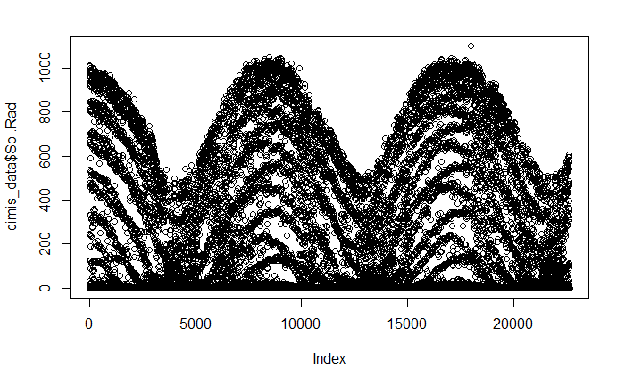

```r
plot(cimis_data$Sol.Rad)
```

```r
cimis_data$time.id<-cimis_data$TIMESTAMP$year+1900+
  (cimis_data$TIMESTAMP$yday)/366+
  (cimis_data$TIMESTAMP$hour)/366/24+
  (cimis_data$TIMESTAMP$min)/366/24/60

cimis_data$time.id[1:50]
```

```
 [1] 2019.495 2019.495 2019.495 2019.495 2019.495 2019.495 2019.495 2019.495 2019.496 2019.496 2019.496 2019.496
[13] 2019.496 2019.496 2019.496 2019.496 2019.496 2019.497 2019.497 2019.497 2019.497 2019.497 2019.497 2019.497
[25] 2019.497 2019.497 2019.498 2019.498 2019.498 2019.498 2019.498 2019.498 2019.498 2019.498 2019.499 2019.499
[37] 2019.499 2019.499 2019.499 2019.499 2019.499 2019.499 2019.499 2019.500 2019.500 2019.500 2019.500 2019.500
[49] 2019.500 2019.500
```

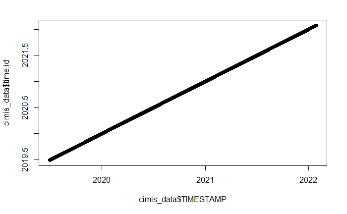

```r
plot(cimis_data$TIMESTAMP,cimis_data$time.id)
```

```r
which(duplicated(cimis_data$time.id))
```

```
integer(0)
```

```r
head(cimis_data)
```

|  | Stn.Id | Stn.Name | CIMIS.Region | Date | Hour | DOY | ETo | qc | Precip | qc.1 | Sol.Rad | qc.2 | Net.Rad | qc.3 | Vap.Pres | qc.4 | Air.Temp | qc.5 | Rel.Hum | qc.6 | Dew.Point | qc.7 | Wind.Speed | qc.8 | Res.Wind.Speed..m.s. | qc.9 | Wind.Dir | qc.10 | Wind.Dir.Std.Dev | … |
| --- | --- | --- | --- | --- | --- | --- | --- | --- | --- | --- | --- | --- | --- | --- | --- | --- | --- | --- | --- | --- | --- | --- | --- | --- | --- | --- | --- | --- | --- | --- |
| 1 | 170 | Concord | San Francisco Bay | 7/1/2019 | 0100 | 182 | 0 |  | 0 |  | 0 |  | -40 |  | 1.4 |  | 14.6 |  | 82 |  | 11.7 |  | 2.2 |  | 1.9 |  | 190 |  | 27 | … |
| 2 | 170 | Concord | San Francisco Bay | 7/1/2019 | 0200 | 182 | 0 |  | 0 |  | 0 |  | -40 |  | 1.4 |  | 14.2 |  | 84 |  | 11.5 |  | 2.0 |  | 1.6 |  | 208 |  | 37 | … |
| 3 | 170 | Concord | San Francisco Bay | 7/1/2019 | 0300 | 182 | 0 |  | 0 |  | 0 |  | -40 |  | 1.4 |  | 14.0 |  | 85 |  | 11.4 |  | 2.2 |  | 1.9 |  | 211 |  | 30 | … |
| 4 | 170 | Concord | San Francisco Bay | 7/1/2019 | 0400 | 182 | 0 |  | 0 |  | 0 |  | -40 |  | 1.4 |  | 13.9 |  | 85 |  | 11.5 |  | 2.0 |  | 1.6 |  | 213 |  | 37 | … |
| 5 | 170 | Concord | San Francisco Bay | 7/1/2019 | 0500 | 182 | 0 |  | 0 |  | 3 |  | -38 |  | 1.4 |  | 13.7 |  | 87 |  | 11.7 |  | 2.0 |  | 1.6 |  | 192 |  | 36 | … |
| 6 | 170 | Concord | San Francisco Bay | 7/1/2019 | 0600 | 182 | 0 |  | 0 |  | 31 |  | -17 |  | 1.4 |  | 14.0 |  | 87 |  | 11.8 |  | 2.1 |  | 1.6 |  | 199 |  | 39 | … |

```r
NA
NA
NA
NA
```

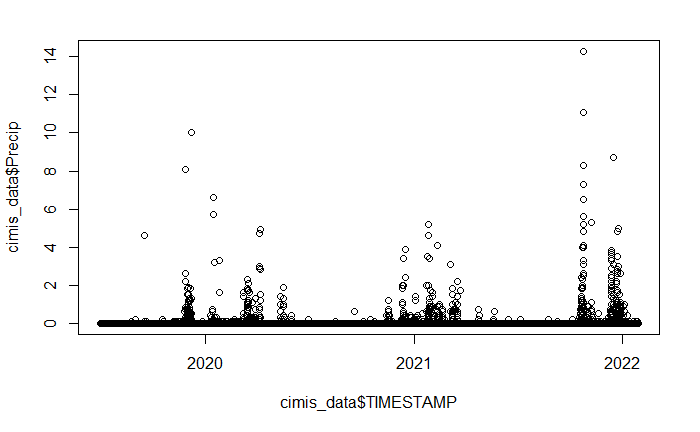

```r
plot(cimis_data$TIMESTAMP, cimis_data$Precip )
```

```r
plot(cumsum(tapply(cimis_data$Precip,
          (cimis_data$DOY),
            function(x) sum(x,na.rm=T))),
     xaxt='n',
     xlab='Days since June 25,2019',
     ylab=expression(Cumulative~Precipitation~'('~mm~')'),
     main='',
     ylim = c(0,700),
     lty=1,
     col="red",
     lwd=2,
     type="l")
abline(v=365, col="blue")
```

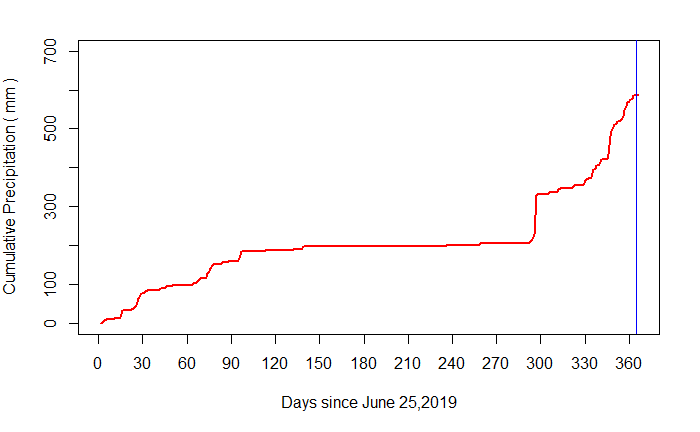

```r
axis(side=1,at=seq(0,1080,by=30))
```

#dropping time id column and creating a new time id so all the exponents line up for eddy_met data

```r
names(eddy_met)[names(eddy_met) == "time.id"] <- "old_time.id"

eddy_met$old_time.id <-NULL

colnames(eddy_met)
```

```
  [1] "TIMESTAMP"                     "filename"                      "date"
  [4] "time"                          "DOY"                           "daytime"
  [7] "file_records"                  "used_records"                  "Tau"
 [10] "qc_Tau"                        "H"                             "qc_H"
 [13] "LE"                            "qc_LE"                         "co2_flux"
 [16] "qc_co2_flux"                   "h2o_flux"                      "qc_h2o_flux"
 [19] "H_strg"                        "LE_strg"                       "co2_strg"
 [22] "h2o_strg"                      "co2_v.adv"                     "h2o_v.adv"
 [25] "co2_molar_density"             "co2_mole_fraction"             "co2_mixing_ratio"
 [28] "co2_time_lag"                  "co2_def_timelag"               "h2o_molar_density"
 [31] "h2o_mole_fraction"             "h2o_mixing_ratio"              "h2o_time_lag"
 [34] "h2o_def_timelag"               "sonic_temperature"             "air_temperature"
 [37] "air_pressure"                  "air_density"                   "air_heat_capacity"
 [40] "air_molar_volume"              "ET"                            "water_vapor_density"
 [43] "e"                             "es"                            "specific_humidity"
```

[output cut: 48 more lines]

#For eddy_met master data switching the timestamp back to a timestamp from being a character vector.

```r
head(eddy_met)
```

|  | TIMESTAMP | filename | date | time | DOY | daytime | file_records | used_records | Tau | qc_Tau | H | qc_H | LE | qc_LE | co2_flux | qc_co2_flux | h2o_flux | qc_h2o_flux | H_strg | LE_strg | co2_strg | h2o_strg | co2_v.adv | h2o_v.adv | co2_molar_density | co2_mole_fraction | co2_mixing_ratio | co2_time_lag | co2_def_timelag | … |
| --- | --- | --- | --- | --- | --- | --- | --- | --- | --- | --- | --- | --- | --- | --- | --- | --- | --- | --- | --- | --- | --- | --- | --- | --- | --- | --- | --- | --- | --- | --- |
| 1 | 7/1/2019 0:00 | 2019-06-30T233000_smart3-00177.ghg | 7/1/2019 | 0:00 | 182.0000 | 0 | 18000 | 18000 | -0.161742 | 0 | -36.9636 | 0 | 13.31220 | 0 | 2.00925 | 0 | 0.300071 | 0 | 0.179553 | -0.015000 | 0.030300 | -0.000338 | -9.53e-11 | -2.54e-12 | 16.6464 | 398.570 | 402.846 | 0 | 0 | … |
| 2 | 7/1/2019 0:30 | 2019-07-01T000000_smart3-00177.ghg | 7/1/2019 | 0:30 | 182.0208 | 0 | 18000 | 18000 | -0.223893 | 0 | -67.1903 | 1 | 32.60920 | 1 | 3.70433 | 1 | 0.734689 | 1 | -1.257440 | 1.371800 | 0.077000 | 0.030900 | 1.62e-10 | 4.46e-12 | 16.7133 | 399.478 | 403.912 | 0 | 0 | … |
| 3 | 7/1/2019 1:00 | 2019-07-01T003000_smart3-00177.ghg | 7/1/2019 | 1:00 | 182.0416 | 0 | 18000 | 18000 | -0.123429 | 0 | -31.6904 | 0 | 3.27048 | 1 | 1.52647 | 0 | 0.073600 | 1 | -2.081560 | 0.081100 | 0.020400 | 0.001830 | 3.87e-11 | 1.07e-12 | 16.7701 | 399.718 | 404.164 | 0 | 0 | … |
| 4 | 7/1/2019 1:30 | 2019-07-01T010000_smart3-00177.ghg | 7/1/2019 | 1:30 | 182.0624 | 0 | 18000 | 18000 | -0.116504 | 1 | -40.3635 | 0 | 11.78860 | 1 | 1.42457 | 0 | 0.265454 | 1 | 0.664646 | -0.137058 | -0.013400 | -0.003090 | -3.12e-11 | -8.56e-13 | 16.7477 | 399.560 | 403.989 | 0 | 0 | … |
| 5 | 7/1/2019 2:00 | 2019-07-01T013000_smart3-00177.ghg | 7/1/2019 | 2:00 | 182.0833 | 0 | 18000 | 18000 | -0.143155 | 0 | -25.2746 | 0 | NA | 2 | 1.54148 | 0 | NA | 2 | -2.911480 | 3.282810 | -0.000759 | 0.073800 | 5.34e-11 | 1.58e-12 | 16.8143 | 399.551 | 404.334 | 0 | 0 | … |
| 6 | 7/1/2019 2:30 | 2019-07-01T020000_smart3-00177.ghg | 7/1/2019 | 2:30 | 182.1041 | 0 | 18000 | 18000 | -0.100744 | 0 | -35.0211 | 0 | 5.26757 | 0 | 1.47403 | 0 | 0.118459 | 0 | -0.493139 | 0.128214 | -0.027500 | 0.002880 | 2.53e-11 | 7.52e-13 | 16.8100 | 399.229 | 404.022 | 0 | 0 | … |

```r
names(eddy_met)[names(eddy_met) == "TIMESTAMP"] <- "fake_timestamp"


colnames(eddy_met)
```

```
  [1] "fake_timestamp"                "filename"                      "date"
  [4] "time"                          "DOY"                           "daytime"
  [7] "file_records"                  "used_records"                  "Tau"
 [10] "qc_Tau"                        "H"                             "qc_H"
 [13] "LE"                            "qc_LE"                         "co2_flux"
 [16] "qc_co2_flux"                   "h2o_flux"                      "qc_h2o_flux"
 [19] "H_strg"                        "LE_strg"                       "co2_strg"
 [22] "h2o_strg"                      "co2_v.adv"                     "h2o_v.adv"
 [25] "co2_molar_density"             "co2_mole_fraction"             "co2_mixing_ratio"
 [28] "co2_time_lag"                  "co2_def_timelag"               "h2o_molar_density"
 [31] "h2o_mole_fraction"             "h2o_mixing_ratio"              "h2o_time_lag"
 [34] "h2o_def_timelag"               "sonic_temperature"             "air_temperature"
 [37] "air_pressure"                  "air_density"                   "air_heat_capacity"
 [40] "air_molar_volume"              "ET"                            "water_vapor_density"
 [43] "e"                             "es"                            "specific_humidity"
```

[output cut: 48 more lines]

```r
head(eddy_met$fake_timestamp)
```

```
[1] "7/1/2019 0:00" "7/1/2019 0:30" "7/1/2019 1:00" "7/1/2019 1:30" "7/1/2019 2:00" "7/1/2019 2:30"
```

```r
eddy_met$TIMESTAMP<-strptime(paste(eddy_met$fake_timestamp),
                          format="%m/%d/%Y %H:%M",
                         tz = "Etc/GMT-8")

head(eddy_met$TIMESTAMP)
```

```
[1] "2019-07-01 00:00:00 +08" "2019-07-01 00:30:00 +08" "2019-07-01 01:00:00 +08" "2019-07-01 01:30:00 +08"
[5] "2019-07-01 02:00:00 +08" "2019-07-01 02:30:00 +08"
```

```r
tail((eddy_met$TIMESTAMP))
```

```
[1] "2022-01-28 08:00:00 +08" "2022-01-28 08:30:00 +08" "2022-01-28 09:00:00 +08" "2022-01-28 09:30:00 +08"
[5] "2022-01-28 10:00:00 +08" "2022-01-28 10:30:00 +08"
```

```r
head(eddy_met)
```

|  | fake_timestamp | filename | date | time | DOY | daytime | file_records | used_records | Tau | qc_Tau | H | qc_H | LE | qc_LE | co2_flux | qc_co2_flux | h2o_flux | qc_h2o_flux | H_strg | LE_strg | co2_strg | h2o_strg | co2_v.adv | h2o_v.adv | co2_molar_density | co2_mole_fraction | co2_mixing_ratio | co2_time_lag | co2_def_timelag | … |
| --- | --- | --- | --- | --- | --- | --- | --- | --- | --- | --- | --- | --- | --- | --- | --- | --- | --- | --- | --- | --- | --- | --- | --- | --- | --- | --- | --- | --- | --- | --- |
| 1 | 7/1/2019 0:00 | 2019-06-30T233000_smart3-00177.ghg | 7/1/2019 | 0:00 | 182.0000 | 0 | 18000 | 18000 | -0.161742 | 0 | -36.9636 | 0 | 13.31220 | 0 | 2.00925 | 0 | 0.300071 | 0 | 0.179553 | -0.015000 | 0.030300 | -0.000338 | -9.53e-11 | -2.54e-12 | 16.6464 | 398.570 | 402.846 | 0 | 0 | … |
| 2 | 7/1/2019 0:30 | 2019-07-01T000000_smart3-00177.ghg | 7/1/2019 | 0:30 | 182.0208 | 0 | 18000 | 18000 | -0.223893 | 0 | -67.1903 | 1 | 32.60920 | 1 | 3.70433 | 1 | 0.734689 | 1 | -1.257440 | 1.371800 | 0.077000 | 0.030900 | 1.62e-10 | 4.46e-12 | 16.7133 | 399.478 | 403.912 | 0 | 0 | … |
| 3 | 7/1/2019 1:00 | 2019-07-01T003000_smart3-00177.ghg | 7/1/2019 | 1:00 | 182.0416 | 0 | 18000 | 18000 | -0.123429 | 0 | -31.6904 | 0 | 3.27048 | 1 | 1.52647 | 0 | 0.073600 | 1 | -2.081560 | 0.081100 | 0.020400 | 0.001830 | 3.87e-11 | 1.07e-12 | 16.7701 | 399.718 | 404.164 | 0 | 0 | … |
| 4 | 7/1/2019 1:30 | 2019-07-01T010000_smart3-00177.ghg | 7/1/2019 | 1:30 | 182.0624 | 0 | 18000 | 18000 | -0.116504 | 1 | -40.3635 | 0 | 11.78860 | 1 | 1.42457 | 0 | 0.265454 | 1 | 0.664646 | -0.137058 | -0.013400 | -0.003090 | -3.12e-11 | -8.56e-13 | 16.7477 | 399.560 | 403.989 | 0 | 0 | … |
| 5 | 7/1/2019 2:00 | 2019-07-01T013000_smart3-00177.ghg | 7/1/2019 | 2:00 | 182.0833 | 0 | 18000 | 18000 | -0.143155 | 0 | -25.2746 | 0 | NA | 2 | 1.54148 | 0 | NA | 2 | -2.911480 | 3.282810 | -0.000759 | 0.073800 | 5.34e-11 | 1.58e-12 | 16.8143 | 399.551 | 404.334 | 0 | 0 | … |
| 6 | 7/1/2019 2:30 | 2019-07-01T020000_smart3-00177.ghg | 7/1/2019 | 2:30 | 182.1041 | 0 | 18000 | 18000 | -0.100744 | 0 | -35.0211 | 0 | 5.26757 | 0 | 1.47403 | 0 | 0.118459 | 0 | -0.493139 | 0.128214 | -0.027500 | 0.002880 | 2.53e-11 | 7.52e-13 | 16.8100 | 399.229 | 404.022 | 0 | 0 | … |

```r
NA
```

#creating a new time.id for eddy_met data

```r
eddy_met$time.id<-eddy_met$TIMESTAMP$year+1900+
  (eddy_met$TIMESTAMP$yday)/366+
  (eddy_met$TIMESTAMP$hour)/366/24+
  (eddy_met$TIMESTAMP$min)/366/24/60

eddy_met$time.id[1:50]
```

```
 [1] 2019.495 2019.495 2019.495 2019.495 2019.495 2019.495 2019.495 2019.495 2019.495 2019.495 2019.495 2019.495
[13] 2019.495 2019.495 2019.495 2019.495 2019.495 2019.496 2019.496 2019.496 2019.496 2019.496 2019.496 2019.496
[25] 2019.496 2019.496 2019.496 2019.496 2019.496 2019.496 2019.496 2019.496 2019.496 2019.496 2019.496 2019.497
[37] 2019.497 2019.497 2019.497 2019.497 2019.497 2019.497 2019.497 2019.497 2019.497 2019.497 2019.497 2019.497
[49] 2019.497 2019.497
```

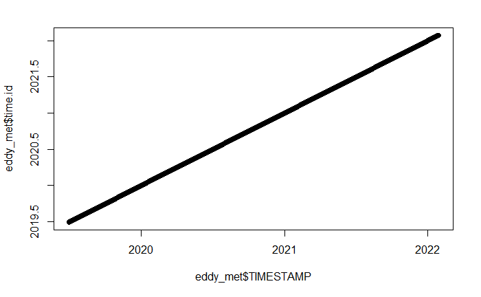

```r
plot(eddy_met$TIMESTAMP,eddy_met$time.id)
```

```r
which(duplicated(eddy_met$time.id))
```

```
integer(0)
```

#removing fake timestamp

```r
eddy_met$fake_timestamp <-NULL


cimis_data$fake_timestamp <- NULL
colnames(eddy_met)
```

```
  [1] "filename"                      "date"                          "time"
  [4] "DOY"                           "daytime"                       "file_records"
  [7] "used_records"                  "Tau"                           "qc_Tau"
 [10] "H"                             "qc_H"                          "LE"
 [13] "qc_LE"                         "co2_flux"                      "qc_co2_flux"
 [16] "h2o_flux"                      "qc_h2o_flux"                   "H_strg"
 [19] "LE_strg"                       "co2_strg"                      "h2o_strg"
 [22] "co2_v.adv"                     "h2o_v.adv"                     "co2_molar_density"
 [25] "co2_mole_fraction"             "co2_mixing_ratio"              "co2_time_lag"
 [28] "co2_def_timelag"               "h2o_molar_density"             "h2o_mole_fraction"
 [31] "h2o_mixing_ratio"              "h2o_time_lag"                  "h2o_def_timelag"
 [34] "sonic_temperature"             "air_temperature"               "air_pressure"
 [37] "air_density"                   "air_heat_capacity"             "air_molar_volume"
 [40] "ET"                            "water_vapor_density"           "e"
 [43] "es"                            "specific_humidity"             "RH"
```

[output cut: 48 more lines]

```r
colnames(cimis_data)
```

```
 [1] "Stn.Id"               "Stn.Name"             "CIMIS.Region"         "Date"                 "Hour"
 [6] "DOY"                  "ETo"                  "qc"                   "Precip"               "qc.1"
[11] "Sol.Rad"              "qc.2"                 "Net.Rad"              "qc.3"                 "Vap.Pres"
[16] "qc.4"                 "Air.Temp"             "qc.5"                 "Rel.Hum"              "qc.6"
[21] "Dew.Point"            "qc.7"                 "Wind.Speed"           "qc.8"                 "Res.Wind.Speed..m.s."
[26] "qc.9"                 "Wind.Dir"             "qc.10"                "Wind.Dir.Std.Dev"     "qc.11"
[31] "Soil.Temp"            "qc.12"                "PM.ETo"               "qc.13"                "PM.ETr"
[36] "qc.14"                "Exp.1"                "Exp.2"                "TIMESTAMP"            "time.id"
```

#merging cimis and combo data based on time.id

```r
cimis_eddy_met<- merge.data.frame(eddy_met,
                         cimis_data[,-which(colnames(cimis_data)=="TIMESTAMP")],
                         by = "time.id",
                         all = TRUE,
                         sort = TRUE)


head(cimis_eddy_met, 50)
```

|  | time.id | filename | date | time | DOY.x | daytime | file_records | used_records | Tau | qc_Tau | H | qc_H | LE | qc_LE | co2_flux | qc_co2_flux | h2o_flux | qc_h2o_flux | H_strg | LE_strg | co2_strg | h2o_strg | co2_v.adv | h2o_v.adv | co2_molar_density | co2_mole_fraction | co2_mixing_ratio | co2_time_lag | co2_def_timelag | … |
| --- | --- | --- | --- | --- | --- | --- | --- | --- | --- | --- | --- | --- | --- | --- | --- | --- | --- | --- | --- | --- | --- | --- | --- | --- | --- | --- | --- | --- | --- | --- |
| 1 | 2019.495 | 2019-06-30T233000_smart3-00177.ghg | 7/1/2019 | 0:00 | 182.0000 | 0 | 18000 | 18000 | -0.161742 | 0 | -36.96360 | 0 | 13.312200 | 0 | 2.009250 | 0 | 0.300071 | 0 | 0.179553 | -0.015000 | 0.030300 | -0.000338 | -9.53e-11 | -2.54e-12 | 16.6464 | 398.570 | 402.846 | 0.0 | 0 | … |
| 2 | 2019.495 | 2019-07-01T000000_smart3-00177.ghg | 7/1/2019 | 0:30 | 182.0208 | 0 | 18000 | 18000 | -0.223893 | 0 | -67.19030 | 1 | 32.609200 | 1 | 3.704330 | 1 | 0.734689 | 1 | -1.257440 | 1.371800 | 0.077000 | 0.030900 | 1.62e-10 | 4.46e-12 | 16.7133 | 399.478 | 403.912 | 0.0 | 0 | … |
| 3 | 2019.495 | 2019-07-01T003000_smart3-00177.ghg | 7/1/2019 | 1:00 | 182.0416 | 0 | 18000 | 18000 | -0.123429 | 0 | -31.69040 | 0 | 3.270480 | 1 | 1.526470 | 0 | 0.073600 | 1 | -2.081560 | 0.081100 | 0.020400 | 0.001830 | 3.87e-11 | 1.07e-12 | 16.7701 | 399.718 | 404.164 | 0.0 | 0 | … |
| 4 | 2019.495 | 2019-07-01T010000_smart3-00177.ghg | 7/1/2019 | 1:30 | 182.0624 | 0 | 18000 | 18000 | -0.116504 | 1 | -40.36350 | 0 | 11.788600 | 1 | 1.424570 | 0 | 0.265454 | 1 | 0.664646 | -0.137058 | -0.013400 | -0.003090 | -3.12e-11 | -8.56e-13 | 16.7477 | 399.560 | 403.989 | 0.0 | 0 | … |
| 5 | 2019.495 | 2019-07-01T013000_smart3-00177.ghg | 7/1/2019 | 2:00 | 182.0833 | 0 | 18000 | 18000 | -0.143155 | 0 | -25.27460 | 0 | NA | 2 | 1.541480 | 0 | NA | 2 | -2.911480 | 3.282810 | -0.000759 | 0.073800 | 5.34e-11 | 1.58e-12 | 16.8143 | 399.551 | 404.334 | 0.0 | 0 | … |
| 6 | 2019.495 | 2019-07-01T020000_smart3-00177.ghg | 7/1/2019 | 2:30 | 182.1041 | 0 | 18000 | 18000 | -0.100744 | 0 | -35.02110 | 0 | 5.267570 | 0 | 1.474030 | 0 | 0.118459 | 0 | -0.493139 | 0.128214 | -0.027500 | 0.002880 | 2.53e-11 | 7.52e-13 | 16.8100 | 399.229 | 404.022 | 0.0 | 0 | … |
| 7 | 2019.495 | 2019-07-01T023000_smart3-00177.ghg | 7/1/2019 | 3:00 | 182.1249 | 0 | 18000 | 18000 | -0.116418 | 0 | -33.30760 | 0 | 1.808150 | 1 | 1.407190 | 0 | 0.040700 | 1 | -0.446794 | 0.904135 | -0.012200 | 0.020300 | 1.50e-11 | 4.55e-13 | 16.8122 | 399.085 | 403.974 | 0.0 | 0 | … |
| 8 | 2019.495 | 2019-07-01T030000_smart3-00177.ghg | 7/1/2019 | 3:30 | 182.1458 | 0 | 18000 | 18000 | -0.095700 | 0 | -32.26780 | 0 | -0.455241 | 1 | 1.294180 | 0 | -0.010200 | 1 | -0.836957 | -0.082500 | 0.002540 | -0.001850 | 3.90e-11 | 1.18e-12 | 16.8340 | 399.115 | 403.995 | 0.1 | 0 | … |
| 9 | 2019.495 | 2019-07-01T033000_smart3-00177.ghg | 7/1/2019 | 4:00 | 182.1666 | 0 | 18000 | 18000 | -0.065100 | 0 | -22.57250 | 0 | 3.243090 | 1 | 1.015990 | 0 | 0.072900 | 1 | 0.131940 | -1.408480 | 0.023000 | -0.031700 | -5.84e-11 | -1.71e-12 | 16.8421 | 399.384 | 404.116 | 0.0 | 0 | … |
| 10 | 2019.495 | 2019-07-01T040000_smart3-00177.ghg | 7/1/2019 | 4:30 | 182.1874 | 1 | 18000 | 18000 | -0.079200 | 0 | -30.66550 | 0 | 2.339350 | 1 | 1.212630 | 0 | 0.052600 | 1 | -0.541747 | 0.231553 | -0.011000 | 0.005200 | 1.40e-11 | 4.12e-13 | 16.8511 | 399.255 | 404.011 | 0.0 | 0 | … |

[output cut: 40 more lines]

```r
tail(cimis_eddy_met, 50)
```

|  | time.id | filename | date | time | DOY.x | daytime | file_records | used_records | Tau | qc_Tau | H | qc_H | LE | qc_LE | co2_flux | qc_co2_flux | h2o_flux | qc_h2o_flux | H_strg | LE_strg | co2_strg | h2o_strg | co2_v.adv | h2o_v.adv | co2_molar_density | co2_mole_fraction | co2_mixing_ratio | co2_time_lag | co2_def_timelag | … |
| --- | --- | --- | --- | --- | --- | --- | --- | --- | --- | --- | --- | --- | --- | --- | --- | --- | --- | --- | --- | --- | --- | --- | --- | --- | --- | --- | --- | --- | --- | --- |
| 45204 | 2022.073 | 2022-01-27T170000_smart3-00177.ghg | 1/27/2022 | 17:30 | 27.7290 | 1 | 18000 | 18000 | -0.002310 | 2 | -19.55310 | 1 | NA | 2 | 6.750180 | 1 | NA | 2 | -5.906940 | 0.294120 | 0.308022 | 6.59e-03 | 1.04e-10 | 1.32e-12 | NA | 432.843 | 435.252 | -0.5 | 0 | … |
| 45205 | 2022.073 | 2022-01-27T173000_smart3-00177.ghg | 1/27/2022 | 18:00 | 27.7498 | 0 | 18000 | 18000 | 0.009430 | 2 | 1.53117 | 0 | NA | 2 | -0.365408 | 1 | NA | 2 | -4.265710 | -1.176300 | 0.786375 | -2.63e-02 | -7.31e-11 | -8.66e-13 | NA | 441.824 | 444.149 | 0.0 | 1 | … |
| 45206 | 2022.073 | 2022-01-27T180000_smart3-00177.ghg | 1/27/2022 | 18:30 | 27.7707 | 0 | 18000 | 18000 | 0.012500 | 0 | 32.18260 | 1 | -14.02900 | 1 | -5.576500 | 1 | -0.313852 | 1 | -0.919662 | 0.001510 | 0.501794 | 3.38e-05 | -1.12e-10 | -1.31e-12 | NA | 447.546 | 449.902 | 0.0 | 1 | … |
| 45207 | 2022.073 | 2022-01-27T183000_smart3-00177.ghg | 1/27/2022 | 19:00 | 27.7915 | 0 | 18000 | 18000 | 0.020500 | 1 | -14.80130 | 1 | 4.42592 | 1 | NA | 2 | 0.099000 | 1 | 0.152938 | -0.139668 | -0.269171 | -3.12e-03 | -1.49e-11 | -1.75e-13 | NA | 444.476 | 446.800 | -0.1 | 0 | … |
| 45208 | 2022.073 | 2022-01-27T190000_smart3-00177.ghg | 1/27/2022 | 19:30 | 27.8123 | 0 | 18000 | 18000 | -0.023300 | 1 | NA | 2 | -4.28404 | 1 | 1.878830 | 0 | -0.095800 | 1 | -0.930174 | 0.398102 | 0.004090 | 8.90e-03 | -5.93e-11 | -7.07e-13 | NA | 444.523 | 446.892 | -0.4 | 0 | … |
| 45209 | 2022.073 | 2022-01-27T193000_smart3-00177.ghg | 1/27/2022 | 20:00 | 27.8332 | 0 | 18000 | 18000 | -0.011300 | 1 | -13.97840 | 0 | 6.46371 | 1 | 2.543120 | 0 | 0.144362 | 1 | -3.743920 | -0.318382 | 0.491908 | -7.11e-03 | 4.89e-12 | 5.68e-14 | NA | 450.095 | 452.458 | -0.1 | 0 | … |
| 45210 | 2022.073 | 2022-01-27T200000_smart3-00177.ghg | 1/27/2022 | 20:30 | 27.8540 | 0 | 18000 | 18000 | 0.035300 | 1 | NA | 2 | -15.11790 | 1 | NA | 2 | -0.337455 | 1 | -1.553880 | -0.455903 | 0.297575 | -1.02e-02 | 1.76e-11 | 1.98e-13 | NA | 453.458 | 455.786 | 0.0 | 1 | … |
| 45211 | 2022.073 | 2022-01-27T203000_smart3-00177.ghg | 1/27/2022 | 21:00 | 27.8748 | 0 | 18000 | 18000 | 0.007000 | 1 | -7.00459 | 1 | 1.65811 | 1 | 1.857410 | 0 | 0.037000 | 1 | -2.763820 | 0.093600 | 0.519688 | 2.09e-03 | 4.38e-11 | 4.89e-13 | NA | 459.306 | 461.675 | 0.0 | 0 | … |
| 45212 | 2022.073 | 2022-01-27T210000_smart3-00177.ghg | 1/27/2022 | 21:30 | 27.8956 | 0 | 18000 | 18000 | -0.014100 | 0 | -4.76845 | 1 | 3.94157 | 1 | 1.029130 | 1 | 0.087800 | 1 | -2.066550 | -0.511699 | -0.206516 | -1.14e-02 | -1.19e-11 | -1.31e-13 | NA | 456.989 | 459.286 | 0.0 | 1 | … |
| 45213 | 2022.074 | 2022-01-27T213000_smart3-00177.ghg | 1/27/2022 | 22:00 | 27.9165 | 0 | 18000 | 18000 | -0.020900 | 1 | NA | 2 | 6.97419 | 1 | 3.532900 | 1 | 0.155359 | 1 | -0.723884 | -0.448048 | -0.522869 | -9.98e-03 | -1.41e-10 | -1.52e-12 | NA | 451.127 | 453.344 | -0.2 | 0 | … |

[output cut: 40 more lines]

```r
NA
```

#updating DOY

```r
cimis_eddy_met$DOY<-cimis_eddy_met$TIMESTAMP$year+1900+
  (cimis_eddy_met$TIMESTAMP$yday)/366

tail(cimis_eddy_met$DOY, 50)
```

```
 [1] 2022.071 2022.071 2022.071 2022.071 2022.071 2022.071 2022.071 2022.071 2022.071 2022.071 2022.071 2022.071
[13] 2022.071 2022.074 2022.074 2022.074 2022.074 2022.074 2022.074 2022.074 2022.074 2022.074 2022.074 2022.074
[25] 2022.074 2022.074 2022.074 2022.074 2022.074 2022.074 2022.074 2022.074 2022.074 2022.074 2022.074       NA
[37]       NA       NA       NA       NA       NA       NA       NA       NA       NA       NA       NA       NA
[49]       NA       NA
```

#filling in missing primary temperature data (hmp) with secondary temperature data (sonic data)

#the intercept and slope need to be updated each time

```r
summary(lm(cimis_eddy_met$AirT_Avg~cimis_eddy_met$air_temperature_adj,na.action=na.omit))
```

```
Call:
lm(formula = cimis_eddy_met$AirT_Avg ~ cimis_eddy_met$air_temperature_adj,
    na.action = na.omit)

Residuals:
     Min       1Q   Median       3Q      Max
-22.7339  -0.2976   0.1330   0.5087   7.5944

Coefficients:
                                    Estimate Std. Error t value Pr(>|t|)
(Intercept)                        1.3268135  0.0162632   81.58   <2e-16 ***
cimis_eddy_met$air_temperature_adj 0.9528243  0.0009664  985.97   <2e-16 ***
---
Signif. codes:  0 ‘***’ 0.001 ‘**’ 0.01 ‘*’ 0.05 ‘.’ 0.1 ‘ ’ 1

Residual standard error: 1.392 on 38301 degrees of freedom
  (6950 observations deleted due to missingness)
Multiple R-squared:  0.9621,    Adjusted R-squared:  0.9621
F-statistic: 9.721e+05 on 1 and 38301 DF,  p-value: < 2.2e-16
```

```r
#the intercept and slope need to be updated each time

 cimis_eddy_met$AirT_predict<- 1.3268135 + 0.9528243*cimis_eddy_met$air_temperature_adj

 cimis_eddy_met$AirT_Avg_GF<-cimis_eddy_met$AirT_Avg

 cimis_eddy_met$AirT_Avg_GF[is.na(cimis_eddy_met$AirT_Avg_GF)]<-cimis_eddy_met$AirT_predict[is.na(cimis_eddy_met$AirT_Avg_GF)]


 summary(cimis_eddy_met$AirT_predict)
```

```
   Min. 1st Qu.  Median    Mean 3rd Qu.    Max.    NA's
 -1.136  10.865  14.859  15.970  20.189  41.688    3433
```

```r
 summary(cimis_eddy_met$AirT_Avg_GF)
```

```
   Min. 1st Qu.  Median    Mean 3rd Qu.    Max.    NA's
 -1.136  10.770  14.950  16.084  20.548  42.350     662
```

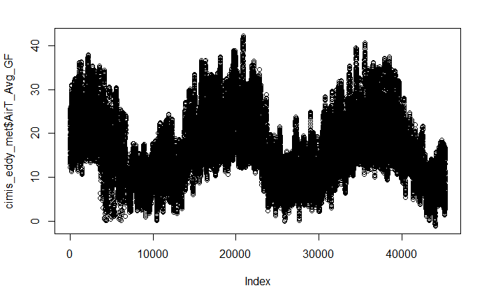

```r
 plot(cimis_eddy_met$AirT_Avg_GF)
```

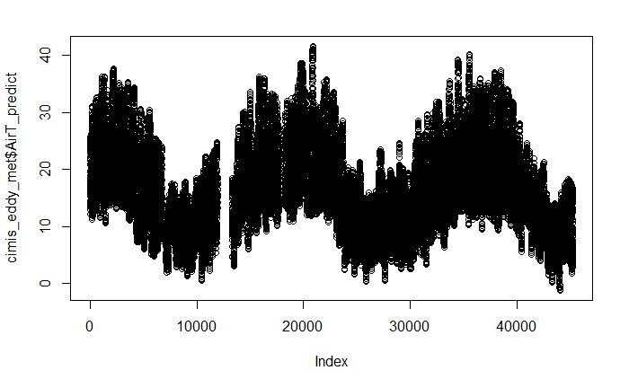

```r
plot(cimis_eddy_met$AirT_predict)
```

#filling in the remaining Temperature NA’s with the values from the CIMIS data

```r
summary(cimis_data$Air.Temp)
```

```
   Min. 1st Qu.  Median    Mean 3rd Qu.    Max.    NA's
  -4.70    9.80   14.70   15.23   19.90   41.80     311
```

```r
summary(cimis_eddy_met$Air.Temp)
```

```
   Min. 1st Qu.  Median    Mean 3rd Qu.    Max.    NA's
  -4.70    9.80   14.70   15.23   19.90   41.80   22931
```

```r
cimis_eddy_met$Air.Temp<-na.approx(cimis_eddy_met$Air.Temp,na.rm=F)
 summary(cimis_eddy_met$Air.Temp)
```

```
   Min. 1st Qu.  Median    Mean 3rd Qu.    Max.    NA's
  -4.70    9.90   14.80   15.28   20.00   41.80       3
```

```r
 cimis_eddy_met$AirT_Avg_GF[is.na(cimis_eddy_met$AirT_Avg_GF)]<-cimis_eddy_met$Air.Temp[is.na(cimis_eddy_met$AirT_Avg_GF)]

summary(cimis_eddy_met$AirT_Avg_GF)
```

```
   Min. 1st Qu.  Median    Mean 3rd Qu.    Max.    NA's
 -1.136  10.750  14.970  16.097  20.590  42.350       1
```

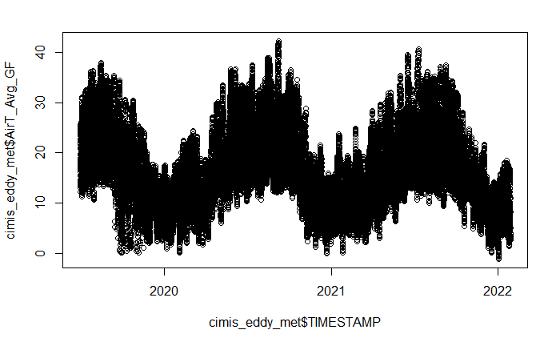

```r
plot(cimis_eddy_met$TIMESTAMP, cimis_eddy_met$AirT_Avg_GF)
```

```r
NA
```

#filling in our precipitation data with Cimis data #Not kosher to gap fill our data with Cimis Data

```r
summary(cimis_data$Precip)
```

```
    Min.  1st Qu.   Median     Mean  3rd Qu.     Max.     NA's
 0.00000  0.00000  0.00000  0.02615  0.00000 14.30000      243
```

```r
# summary(cimis_eddy_met$Precip)
#
# cimis_eddy_met$Precip<-na.approx(cimis_eddy_met$Precip,na.rm=F)
#  summary(cimis_eddy_met$Precip)
#
#
#  cimis_eddy_met$Precip_mm_Tot[is.na(cimis_eddy_met$Precip_mm_Tot)]<-cimis_eddy_met$Precip[is.na(cimis_eddy_met$Precip_mm_Tot)]
#
# summary(cimis_eddy_met$Precip_mm_Tot)



#####################################################
##ploting and comparing our gap filled to CIMIS t
# plot(cimis_eddy_met$TIMESTAMP, cimis_eddy_met$Precip_mm_Tot)
#
# plot(cimis_data$Precip)
#
# plot(cumsum(tapply(cimis_data$Precip,
#           (cimis_data$DOY),
#             function(x) sum(x,na.rm=T))),
#      xaxt='n',
#      xlab='Days since June 25,2019',
#      ylab=expression(Cumulative~Precipitation~'('~mm~')'),
#      main='',
#      ylim = c(0,250),
#      lty=1,
#      col="red",
#      lwd=2,
#      type="l")
# abline(v=365, col="blue")
# axis(side=1,at=seq(0,450,by=30))
#
# plot(cumsum(tapply(cimis_eddy_met$Precip_mm_Tot,
#           (cimis_eddy_met$DOY),
#             function(x) sum(x,na.rm=T))),
#      xaxt='n',
#      xlab='Days since June 25,2019',
#      ylab=expression(Cumulative~Precipitation~'('~mm~')'),
#      main='',
#      ylim = c(0,500),
#      lty=1,
#      col="red",
#      lwd=2,
#      type="l")
# abline(v=365, col="blue")
# axis(side=1,at=seq(0,450,by=30))
```

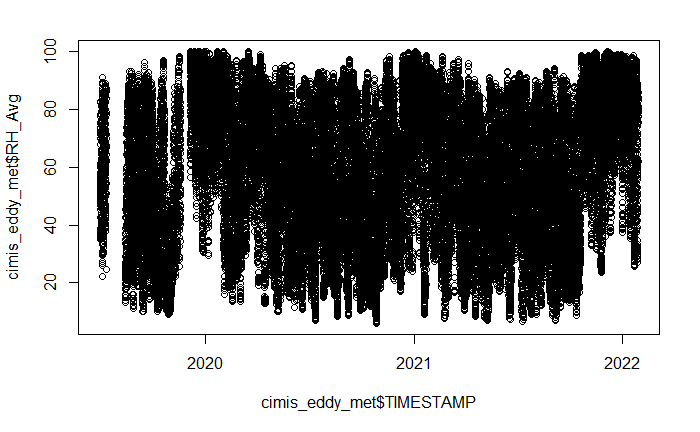

```r
#hmp rh
plot(cimis_eddy_met$TIMESTAMP, cimis_eddy_met$RH_Avg )
```

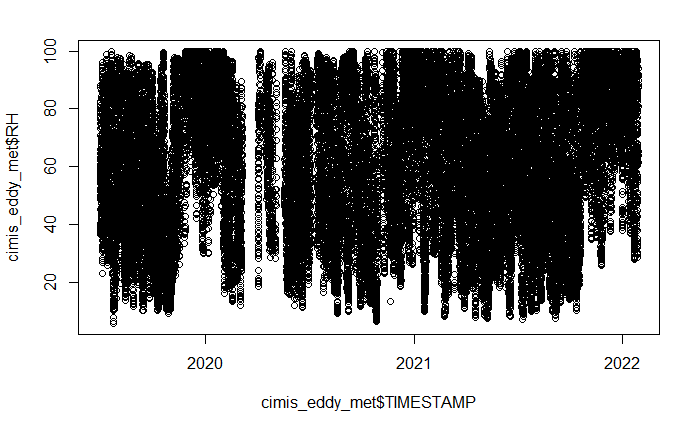

```r
#licor rh
plot(cimis_eddy_met$TIMESTAMP, cimis_eddy_met$RH )
```

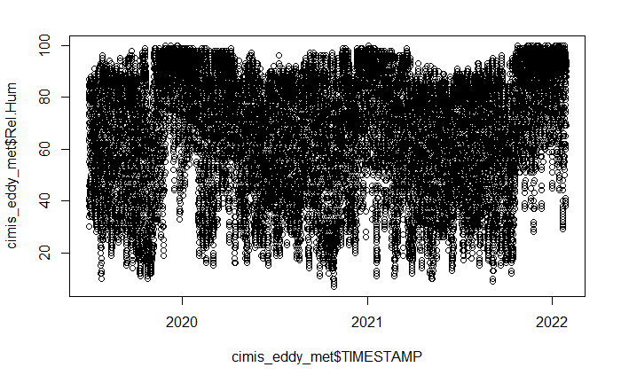

```r
#cimis rh
plot(cimis_eddy_met$TIMESTAMP, cimis_eddy_met$Rel.Hum )
```

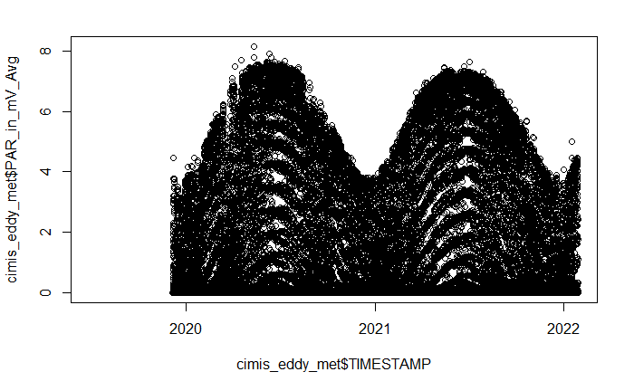

```r
plot(cimis_eddy_met$TIMESTAMP, cimis_eddy_met$PAR_in_mV_Avg)
```

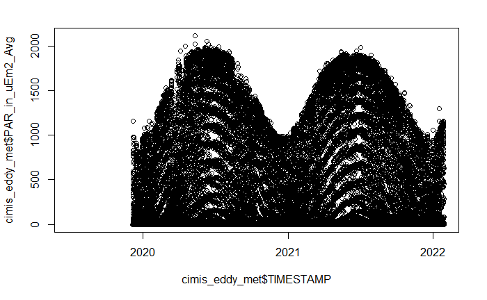

```r
plot(cimis_eddy_met$TIMESTAMP, cimis_eddy_met$PAR_in_uEm2_Avg )
```

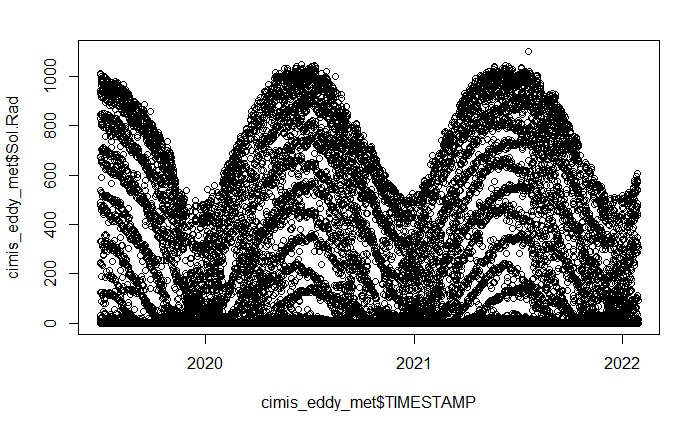

```r
plot(cimis_eddy_met$TIMESTAMP, cimis_eddy_met$Sol.Rad )
```

```r
NA
NA
```

#filling in missing Rh avg (hmp) data with secondary sensor (licor) RH data

```r
summary(lm(cimis_eddy_met$RH_Avg~cimis_eddy_met$RH,na.action=na.omit))
```

```
Call:
lm(formula = cimis_eddy_met$RH_Avg ~ cimis_eddy_met$RH, na.action = na.omit)

Residuals:
    Min      1Q  Median      3Q     Max
-48.742  -1.971  -0.378   1.442  51.130

Coefficients:
                  Estimate Std. Error t value Pr(>|t|)
(Intercept)       1.172391   0.067076   17.48   <2e-16 ***
cimis_eddy_met$RH 0.915162   0.001015  901.83   <2e-16 ***
---
Signif. codes:  0 ‘***’ 0.001 ‘**’ 0.01 ‘*’ 0.05 ‘.’ 0.1 ‘ ’ 1

Residual standard error: 4.722 on 35739 degrees of freedom
  (9512 observations deleted due to missingness)
Multiple R-squared:  0.9579,    Adjusted R-squared:  0.9579
F-statistic: 8.133e+05 on 1 and 35739 DF,  p-value: < 2.2e-16
```

```r
#neeed to update the intercept and slope each time

 cimis_eddy_met$RH_predict<- 1.172391  + 0.915162*cimis_eddy_met$RH

 cimis_eddy_met$RH_Avg_GF<-cimis_eddy_met$RH_Avg

 cimis_eddy_met$RH_Avg_GF[is.na(cimis_eddy_met$RH_Avg_GF)]<-cimis_eddy_met$RH_predict[is.na(cimis_eddy_met$RH_Avg_GF)]


 summary(cimis_eddy_met$RH_predict)
```

```
   Min. 1st Qu.  Median    Mean 3rd Qu.    Max.    NA's
  6.535  38.717  59.120  57.453  77.018  92.689    7484
```

```r
 summary(cimis_eddy_met$RH_Avg_GF)
```

```
   Min. 1st Qu.  Median    Mean 3rd Qu.    Max.    NA's
  6.113  39.200  60.310  58.447  78.720 100.000     839
```

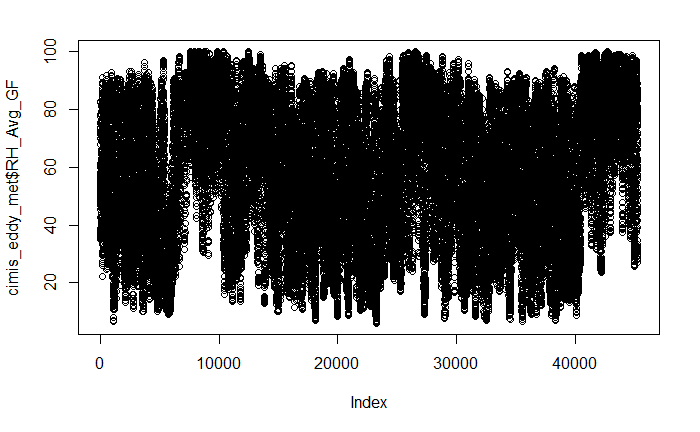

```r
 plot(cimis_eddy_met$RH_Avg_GF)
```

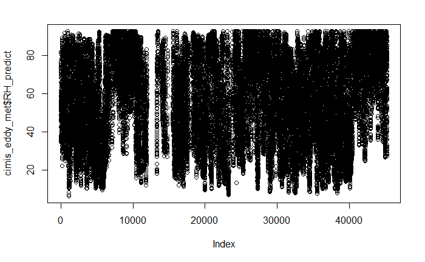

```r
plot(cimis_eddy_met$RH_predict)
```

#filling in remaining RH NA’s with CIMIS data

```r
summary(cimis_data$Rel.Hum)
```

```
   Min. 1st Qu.  Median    Mean 3rd Qu.    Max.    NA's
   7.00   50.00   72.00   67.14   86.00  100.00     312
```

```r
summary(cimis_eddy_met$Rel.Hum)
```

```
   Min. 1st Qu.  Median    Mean 3rd Qu.    Max.    NA's
   7.00   50.00   72.00   67.14   86.00  100.00   22932
```

```r
cimis_eddy_met$Rel.Hum<-na.approx(cimis_eddy_met$Rel.Hum,na.rm=F)
 summary(cimis_eddy_met$Rel.Hum)
```

```
   Min. 1st Qu.  Median    Mean 3rd Qu.    Max.    NA's
   7.00   50.00   71.50   67.13   86.00  100.00       3
```

```r
 cimis_eddy_met$RH_Avg_GF[is.na(cimis_eddy_met$RH_Avg_GF)]<-cimis_eddy_met$Rel.Hum[is.na(cimis_eddy_met$RH_Avg_GF)]

summary(cimis_eddy_met$RH_Avg_GF)
```

```
   Min. 1st Qu.  Median    Mean 3rd Qu.    Max.    NA's
  6.113  39.438  60.500  58.689  79.010 100.000       1
```

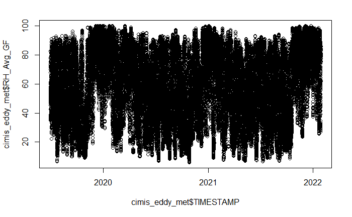

```r
plot(cimis_eddy_met$TIMESTAMP, cimis_eddy_met$RH_Avg_GF)
```

#Incoming solar radiation

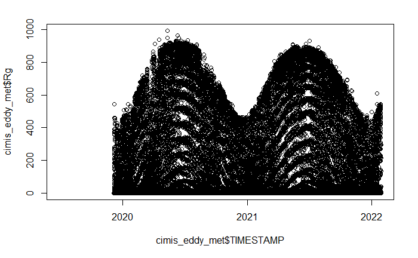

```r
#Rg Calculated from tower's PAR sensors
plot(cimis_eddy_met$TIMESTAMP, cimis_eddy_met$Rg)
```

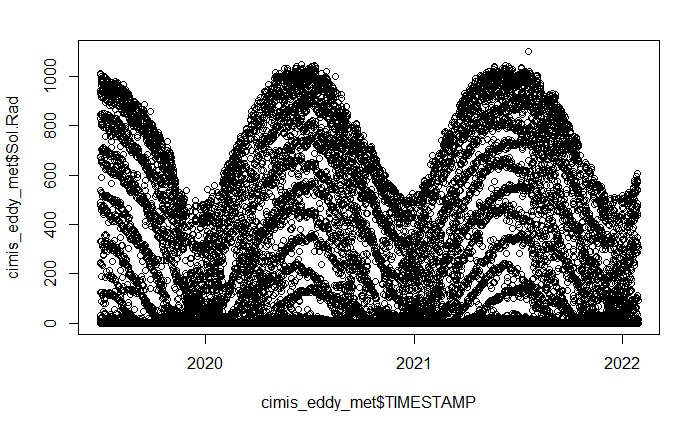

```r
#CIMIS
plot(cimis_eddy_met$TIMESTAMP, cimis_eddy_met$Sol.Rad)
```

```r
summary(cimis_data$Sol.Rad)
```

```
   Min. 1st Qu.  Median    Mean 3rd Qu.    Max.    NA's
    0.0     0.0     9.0   218.8   419.0  1102.0     251
```

```r
#filling in half hour data points for CIMIS data
cimis_eddy_met$Sol.Rad<-na.approx(cimis_eddy_met$Sol.Rad,na.rm=F)

summary(cimis_eddy_met$Sol.Rad)
```

```
   Min. 1st Qu.  Median    Mean 3rd Qu.    Max.    NA's
   0.00    0.00   12.35  217.09  412.00 1102.00       3
```

```r
 summary(cimis_eddy_met$Rg)
```

```
   Min. 1st Qu.  Median    Mean 3rd Qu.    Max.    NA's
  0.000   0.000   5.001 190.102 357.971 995.246    7670
```

```r
 #linear model looking at cimis data and our PAR data
 summary(lm(cimis_eddy_met$Rg ~ cimis_eddy_met$Sol.Rad -1,na.action=na.omit))
```

```
Call:
lm(formula = cimis_eddy_met$Rg ~ cimis_eddy_met$Sol.Rad - 1,
    na.action = na.omit)

Residuals:
    Min      1Q  Median      3Q     Max
-654.25   -5.68    0.00   11.92  588.87

Coefficients:
                        Estimate Std. Error t value Pr(>|t|)
cimis_eddy_met$Sol.Rad 0.8747040  0.0008531    1025   <2e-16 ***
---
Signif. codes:  0 ‘***’ 0.001 ‘**’ 0.01 ‘*’ 0.05 ‘.’ 0.1 ‘ ’ 1

Residual standard error: 61.05 on 37582 degrees of freedom
  (7670 observations deleted due to missingness)
Multiple R-squared:  0.9655,    Adjusted R-squared:  0.9655
F-statistic: 1.051e+06 on 1 and 37582 DF,  p-value: < 2.2e-16
```

```r
 #applying this model to CIMIS data  (just applying coeeficient. no intercept)
 #need to update slope/coefficent everytime
cimis_eddy_met$Rg_predict<-cimis_eddy_met$Sol.Rad* 0.8747040

  summary(cimis_eddy_met$Rg_predict)
```

```
   Min. 1st Qu.  Median    Mean 3rd Qu.    Max.    NA's
    0.0     0.0    10.8   189.9   360.4   963.9       3
```

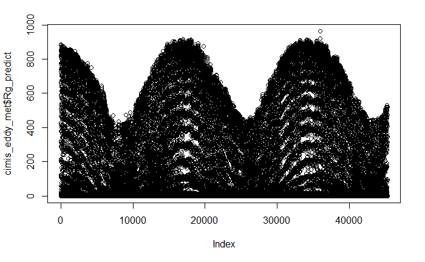

```r
  plot(cimis_eddy_met$Rg_predict)
```

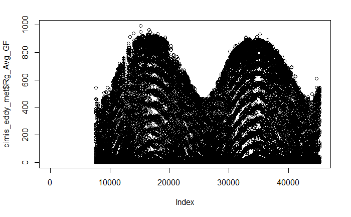

```r
 cimis_eddy_met$Rg_Avg_GF<-cimis_eddy_met$Rg

 plot(cimis_eddy_met$Rg_Avg_GF)
```

```r
 #filling in incoming radiation NA's with CIMIS incoming radiation linearly adjusted data
 cimis_eddy_met$Rg_Avg_GF[is.na(cimis_eddy_met$Rg_Avg_GF)]<-cimis_eddy_met$Rg_predict[is.na(cimis_eddy_met$Rg_Avg_GF)]


 summary(cimis_eddy_met$Rg_predict)
```

```
   Min. 1st Qu.  Median    Mean 3rd Qu.    Max.    NA's
    0.0     0.0    10.8   189.9   360.4   963.9       3
```

```r
 summary(cimis_eddy_met$Rg_Avg_GF)
```

```
   Min. 1st Qu.  Median    Mean 3rd Qu.    Max.    NA's
   0.00    0.00    7.44  192.68  368.09  995.25       3
```

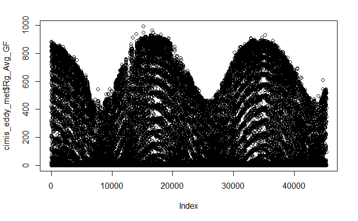

```r
 plot(cimis_eddy_met$Rg_Avg_GF)
```

```r
NA
NA
NA
NA
```

#combining thermocouple 4 ,9 and 14 data. to get mean soil temperature to 15 cm. gap filling with CIMIS data

```r
cimis_eddy_met$Soil_temp_tower_15cm <- apply(cimis_eddy_met[,c('TC_Avg.4.', 'TC_Avg.9.' , 'TC_Avg.14.')], 1, function(x) mean(x))

summary(cimis_eddy_met$Soil_temp_tower_15cm)
```

```
   Min. 1st Qu.  Median    Mean 3rd Qu.    Max.    NA's
  7.214  12.490  18.733  19.272  26.250  33.497    7128
```

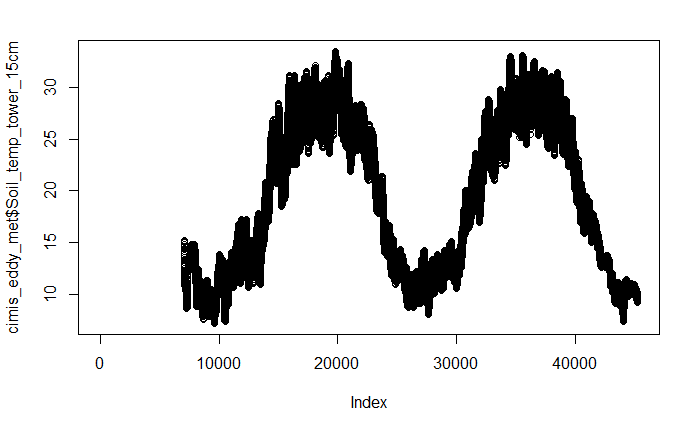

```r
plot(cimis_eddy_met$Soil_temp_tower_15cm)
```

#gap filling for the 15cm soil temp with the CIMIS soil temperatures

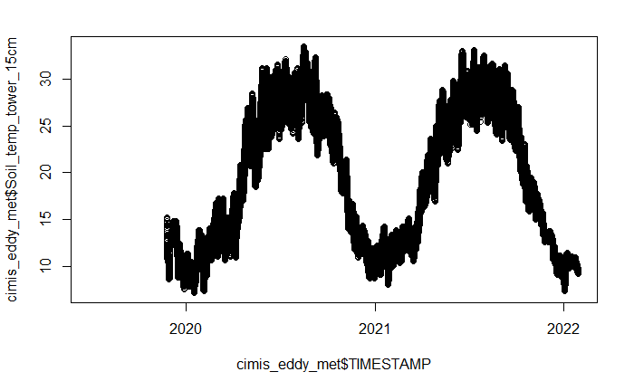

```r
#Soil temp Calculated from tower's thermocouples sensors
plot(cimis_eddy_met$TIMESTAMP, cimis_eddy_met$Soil_temp_tower_15cm)
```

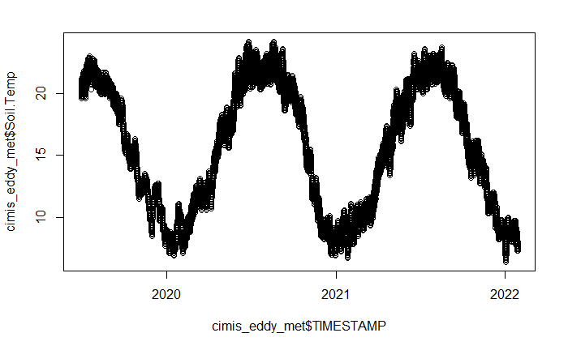

```r
#CIMIS
plot(cimis_eddy_met$TIMESTAMP, cimis_eddy_met$Soil.Temp)
```

```r
summary(cimis_eddy_met$Soil.Temp)
```

```
   Min. 1st Qu.  Median    Mean 3rd Qu.    Max.    NA's
   6.40   10.60   15.50   15.49   20.50   24.20   22870
```

```r
summary(cimis_eddy_met$Soil_temp_tower_15cm)
```

```
   Min. 1st Qu.  Median    Mean 3rd Qu.    Max.    NA's
  7.214  12.490  18.733  19.272  26.250  33.497    7128
```

```r
#filling in half hour data points for CIMIS data
cimis_eddy_met$Soil.Temp<-na.approx(cimis_eddy_met$Soil.Temp,na.rm=F)

summary(cimis_eddy_met$Soil.Temp)
```

```
   Min. 1st Qu.  Median    Mean 3rd Qu.    Max.    NA's
   6.40   10.65   15.60   15.53   20.55   24.20       3
```

```r
 summary(cimis_eddy_met$Soil_temp_tower_15cm)
```

```
   Min. 1st Qu.  Median    Mean 3rd Qu.    Max.    NA's
  7.214  12.490  18.733  19.272  26.250  33.497    7128
```

```r
 #linear model looking at cimis data and our temp data
 summary(lm(cimis_eddy_met$Soil_temp_tower_15cm ~ cimis_eddy_met$Soil.Temp,na.action=na.omit))
```

```
Call:
lm(formula = cimis_eddy_met$Soil_temp_tower_15cm ~ cimis_eddy_met$Soil.Temp,
    na.action = na.omit)

Residuals:
    Min      1Q  Median      3Q     Max
-3.7590 -0.8214 -0.0032  0.7915  4.5775

Coefficients:
                         Estimate Std. Error t value Pr(>|t|)
(Intercept)              -1.60962    0.01816  -88.62   <2e-16 ***
cimis_eddy_met$Soil.Temp  1.38418    0.00114 1214.59   <2e-16 ***
---
Signif. codes:  0 ‘***’ 0.001 ‘**’ 0.01 ‘*’ 0.05 ‘.’ 0.1 ‘ ’ 1

Residual standard error: 1.144 on 38123 degrees of freedom
  (7128 observations deleted due to missingness)
Multiple R-squared:  0.9748,    Adjusted R-squared:  0.9748
F-statistic: 1.475e+06 on 1 and 38123 DF,  p-value: < 2.2e-16
```

```r
 #applying this model to CIMIS data
cimis_eddy_met$Soil_temp_predict_15cm<-cimis_eddy_met$Soil.Temp* 1.38418  - 1.60962

  summary(cimis_eddy_met$Soil_temp_predict_15cm)
```

```
   Min. 1st Qu.  Median    Mean 3rd Qu.    Max.    NA's
  7.249  13.132  19.984  19.893  26.835  31.888       3
```

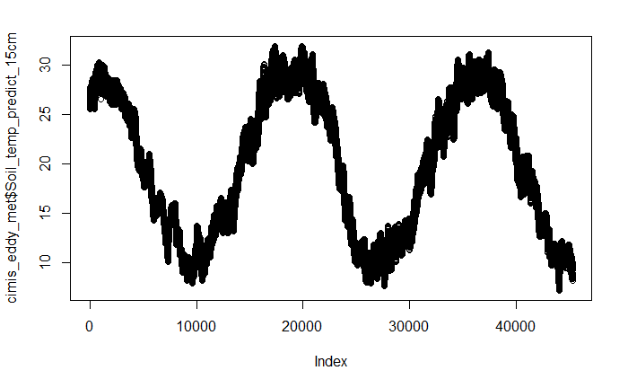

```r
  plot(cimis_eddy_met$Soil_temp_predict_15cm)
```

```r
  summary(cimis_eddy_met$Soil_temp_tower_15cm)
```

```
   Min. 1st Qu.  Median    Mean 3rd Qu.    Max.    NA's
  7.214  12.490  18.733  19.272  26.250  33.497    7128
```

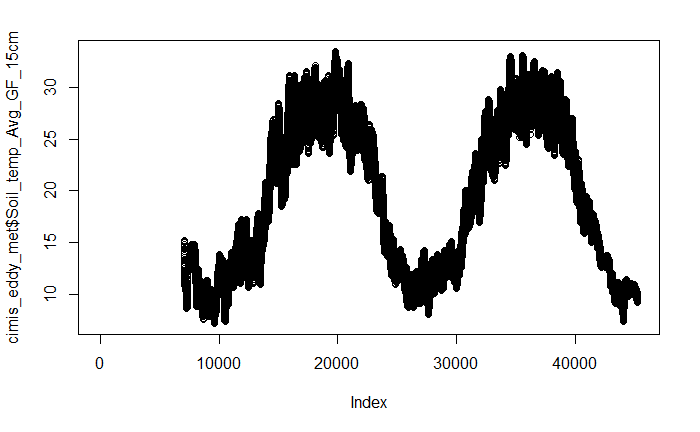

```r
 cimis_eddy_met$Soil_temp_Avg_GF_15cm<-cimis_eddy_met$Soil_temp_tower_15cm

 plot(cimis_eddy_met$Soil_temp_Avg_GF_15cm)
```

```r
 #filling icoming soil temp data with CIMIS templinearly adjusted data
 cimis_eddy_met$Soil_temp_Avg_GF_15cm[is.na(cimis_eddy_met$Soil_temp_Avg_GF_15cm)]<-cimis_eddy_met$Soil_temp_predict_15cm[is.na(cimis_eddy_met$Soil_temp_Avg_GF_15cm)]


 summary(cimis_eddy_met$Soil_temp_predict_15cm)
```

```
   Min. 1st Qu.  Median    Mean 3rd Qu.    Max.    NA's
  7.249  13.132  19.984  19.893  26.835  31.888       3
```

```r
 summary(cimis_eddy_met$Soil_temp_Avg_GF_15cm)
```

```
   Min. 1st Qu.  Median    Mean 3rd Qu.    Max.    NA's
  7.214  13.020  20.053  19.893  26.620  33.497       3
```

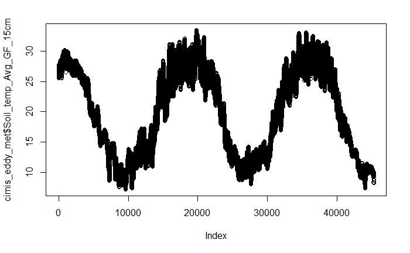

```r
 plot(cimis_eddy_met$Soil_temp_Avg_GF_15cm)
```